## Assignment 2

- Execute the code in the chunk below to read in the data.
  - If there is an error, check to see if there is a `data` directory two directories up that contains the data file.
- Post questions on our Piazza site, visit the Learning Center, or attend office hours if you have questions.

### 1

The following code makes a histogram of the `days` variable in the Lake Monona data set.

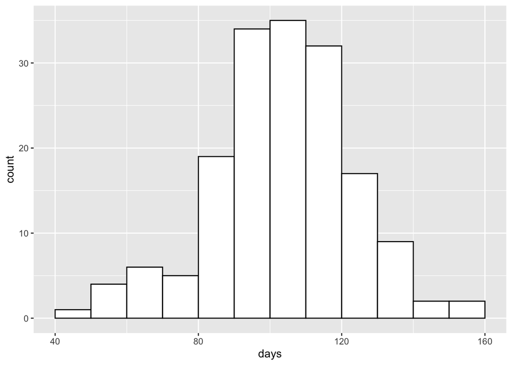

```r
ggplot(monona, aes(x=days)) +
  geom_histogram(boundary=0,binwidth=10,color="black",fill="white")
```

Approximately how many winters had between 40 to 70 days where Lake Monona was at least 50% covered with ice?

### Response

Lake Monona had approximately 11 winters that was at least 50% covered with ice.

### 2

Modify the code below so that:

- one of the bin boundaries is at 70 days
- the width of each bin is 5 days
- the fill color is “cyan”
- the color outlining the bars is “red”
- the x label says “Days Closed with Ice”
- the y label says “Total”
- there is a title with words of your choosing that describe the figure

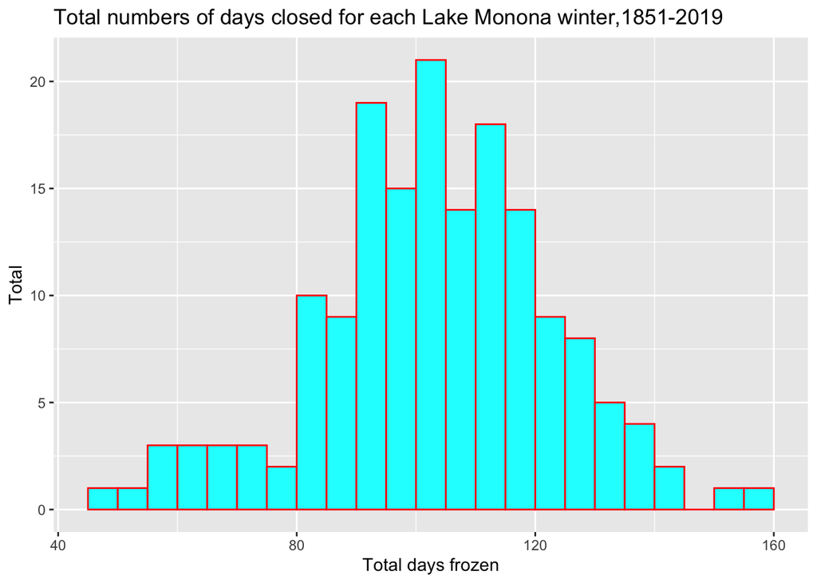

```r
ggplot(monona, aes(x = days)) +
  geom_histogram(boundary=70,binwidth=5,color="red",fill="cyan") +
  xlab("Total days frozen") + ylab("Total") +
  ggtitle("Total numbers of days closed for each Lake Monona winter,1851-2019")
```

### 3

Code in the next chunk makes a scatter plot that shows how the variable `days` changes with time (using `year1`).

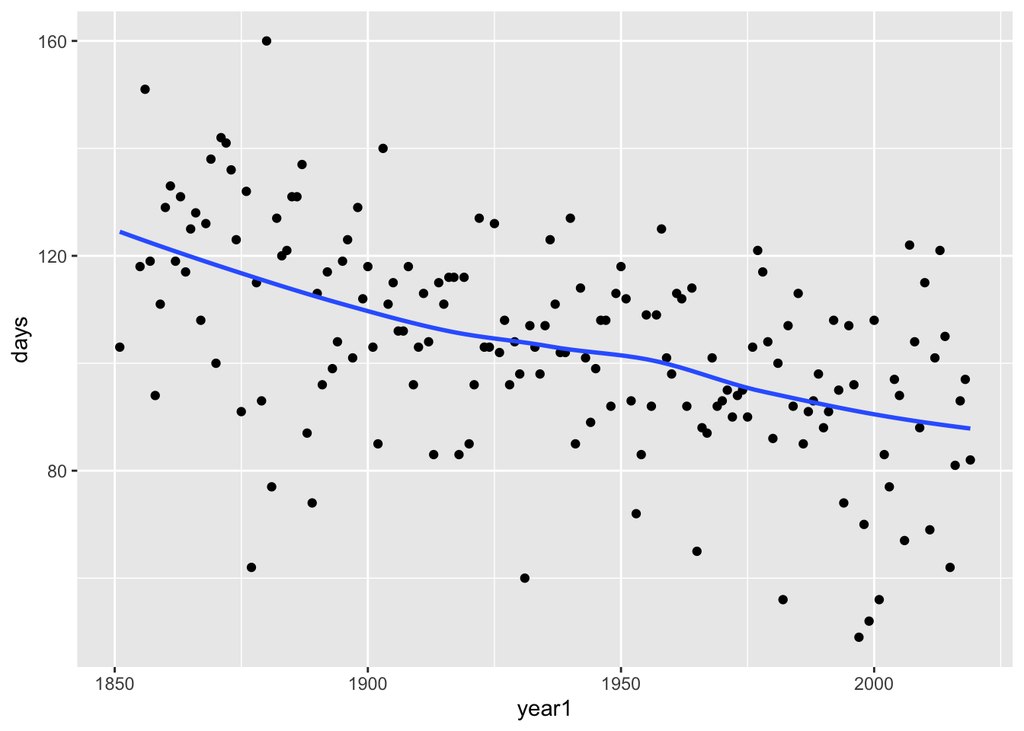

```r
ggplot(monona,aes(x = year1, y = days)) +
  geom_point() +
  geom_smooth(se=FALSE)
```

- What does the line of code `geom_smooth(se=FALSE)` do? (Explain what it does on the graphic; you don’t need to explain details of the method.)
- Describe the pattern of the curve.
- How long was Lake Monona closed with ice in a typical year near 1875 (i.e., what is the approximate value of the smooth curve around 1875)?
- How long was Lake Monona closed with ice in a typical year near 2000 (i.e., what is the approximate value of the smooth curve around 2000)?

### Response

The geom_smooth() method add a smooth trend line to the data. The se=FALSE can get rid of the band of standard error(confidence) from showing up on the scatter plot.

The pattern of the cruve shows a negative relationship between year and days closed. In other word, in recent winter years, the numbers of days closed for Lake Monona is becoming lesser. Therefore, the curve shows a decreasing pattern.

Approximate value of smooth curve around 1875 is around 118 days.

Approximate value of smooth curve around 2000 is around 90 days.

### 4

Modify the code in the following chunk so that:

- There is a box plot displaying the distribution of the days frozen by ice
- The box plot fill color is “yellow”
- The color of the edges of the box plot is “magenta”
- There is a more descriptive y-axis label
- There is an informative plot title

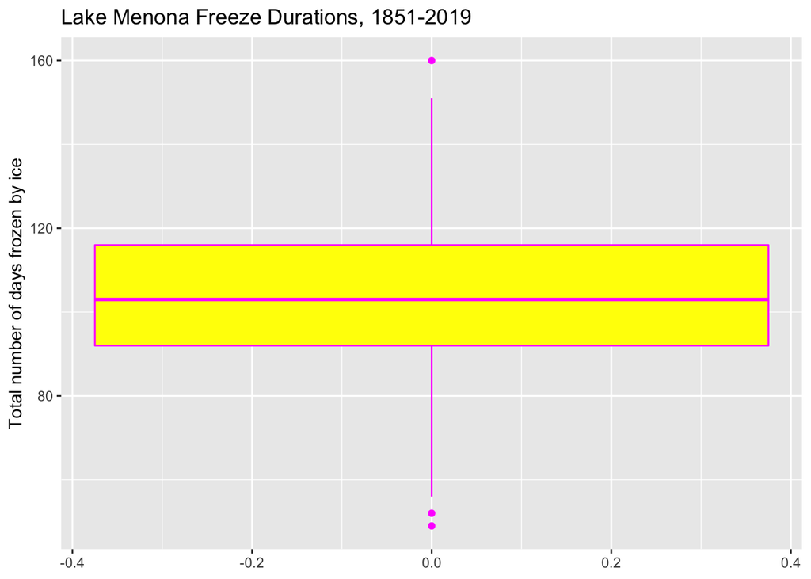

```r
ggplot(data = monona, mapping = aes(y=days)) + geom_boxplot(color="magenta",fill="yellow") + ylab("Total number of days frozen by ice") + ggtitle("Lake Menona Freeze Durations, 1851-2019")
```

- What is the approximate median number of days Lake Monona has been closed with ice?

The approximate median number of days Lake Mona has been closed with ice is 103.